# act_report

## Act Report

This report speaks on the insights and visualizations from the data-wrangling project done.

From the wrangle report, we learned that the gathering, assessing and cleaning processes was performed on the three datasets gotten from the tweet archive of the twitter user @dog_rates also known as WeRateDogs.

The three datasets were then combined after the various processes (gather, assess, clean) were performed on them to give us a master dataset which was saved into the csv file named 'twitter_archive_master.csv'.

The master dataset was read and loaded into the project using the '.read_csv()' function found in the pandas library. Then the histograms of the columns in dataset which had figures was generated.

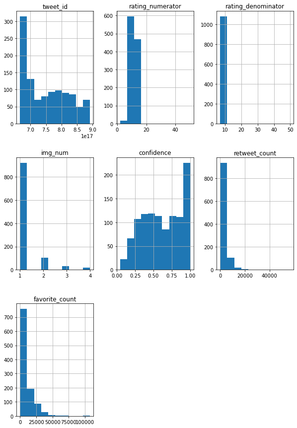

##### Fig. 1: Histogram of all number based columns.

Retweet_id column has an object datatype.

Three instances were looked at and they are:

- Retweet count vs favorite count
- Ratings distribution using the rating_numerator column
- Checking which dog had the highest confidence evoked.

### Retweet Count Vs Favorite Count

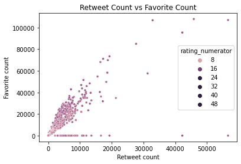

##### Fig. 2: Retweet Count vs Favorite Count using the seaborn scatter plot using the rating_numerator column as the hue

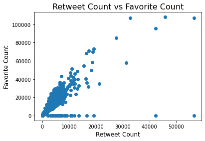

##### Fig. 3: Retweet Count vs Favorite Count Scatter plot

#### Insights gained from the Retweet count vs Favorite Count plots

- The relationship between the retweet_count and favorite_count from the scatter plots could form a straight line.

### Ratings Distribution using the rating_numerator column

Insights were gained through the histogram plotted.

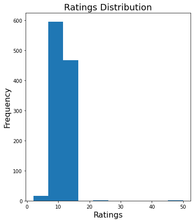

##### Fig. 4: Histogram of the Ratings Distribution

#### Insight gained Ratings distribution histogram

- There are more ratings in the rating_numerator that are between 0 and 20 but not 0 nor 20.

### Checking which dog had the highest confidence evoked

A histogram was plotted for the confidence column to see the frequency.

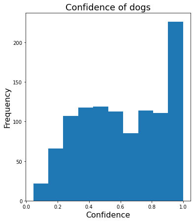

##### Fig. 6: Confidence of Dogs Histogram

The max() function with the mean() was used with the columns dog_type, confidence and tweet_id column to determine the dog type with the highest confidence.